# draft

**Impact of Interstock and Rootstock on the Growth and Productivity of Mango (*Mangifera indica* L.) in the San Lorenzo Valley, Peru**

Sebastian Casas-Niño<sup>1,2</sup>; Sandy Vilchez-Navarro<sup>1,3</sup>; Henry Morocho-Romero<sup>1,3</sup>; Gabriela Cárdenas-Huamán<sup>1,2</sup>; Nery Tirabante-Terrones<sup>1</sup>; Esdwin-Oberti Nuñez-Ticliahunca<sup>1,3</sup>; Ana Montañez-Artica<sup>1</sup>; Leslie Velarde-Apaza<sup>1</sup>; Max Ramirez Rojas<sup>1</sup>; Juancarlos Cruz<sup>1</sup>; Flavio Lozano-Isla^1, 4*^.

*<sup>1</sup> Dirección de Supervisión y Monitoreo en las Estaciones Experimentales Agrarias, Instituto Nacional de Innovación Agraria. Lima. Perú.*

*<sup>2</sup> Universidad Nacional Agraria La Molina (UNALM), Lima, Perú.*

*<sup>3</sup> Universidad Nacional de Piura, Campus Universitario s/n. Urb. Miraflores. Piura, Perú.*

*<sup>4</sup> Facultad de Ingeniería y Ciencias Agrarias, Universidad Nacional Toribio Rodríguez de Mendoza de Amazonas (UNTRM), Chachapoyas, Perú.*

* Corresponding author: flavio.lozano@untrm.edu.pe

ORCID IDs:

Sebastian Casas-Niño: 0000-0002-6576-8761

Sandy Vilchez-Navarro: 0009-0002-1784-5563

Henry Morocho-Romero: 0000-0002-1520-2372

Gabriela Cárdenas-Huamán: 0000-0002-8379-5464

Nery Tirabante-Terrones: 0000-0002-0634-1522

Edwin-Oberti Nuñez-Ticliahuanca: 0009-0004-4613-0625

Ana-Gabriela Montañez-Artica: 0000-0003-3580-6621

Leslie Diana Velarde-Apaza: 0000-0001-6031-6355

Max Ramirez Rojas: 0000-0003-3322-0838

Juancarlos Cruz: 0009-0005-8288-2768

Flavio Lozano-Isla: 0000-0002-0714-669X

**Statements and Declarations**

**Funding**

This work was funded by the National Institute of Agricultural Innovation (INIA), Peru, through investment project No. 2472190 ‘El Chira’.

**Conflicts of interest**

The authors declare that they have no conflicts of interest.

**Author Contributions**

Conceptualization, S.C-N.; methodology, H.M-R.; formal analysis, F.L-I. and S.C-N.; investigation, E-O.N-T.; data curation, F.L-I., and S.C-N.; writing—original draft preparation, H.M-R., S.V-N., G.C-H, N.T-T, E-O.N-T, A.M-A, F.L-I. and S.C-N.; writing—review and editing, F.L-I. and L.V-A.; visualization, F.L-I. and S.C-N.; supervision, J.C. and M.R.; funding acquisition, J.C. All authors have read and agreed to the published version of the manuscript.

**Acknowledgments**

To Engineer Ulises Vladimir Vega Rodriguez and Technician Santos Neri Porras Meca for providing the plant material and performing the grafts in the nursery and field.

**Data availability**

The original contributions presented in this study are included in the article and supplementary material. The reproducible data analysis and datasets are available in Supplementary File 1 and can be accessed through the GitHub repository at: **[https://github.com/Sebass96/prochira_injertos](https://github.com/Sebass96/prochira_injertos.git)**

# 1 **ABSTRACT**

**Keywords:** agronomic performance; biometric characteristics; fruit yield; grafting techniques; El Niño

# 2 **INTRODUCTION**

The mango tree (*Mangifera indica* L.) is a fruit tree of the Anacardiaceae family that is cultivated in tropical and subtropical areas [(Honja, 2014)](https://www.zotero.org/google-docs/?KYtL53). It is characterized by vigorous growth and aesthetically attractive fruits, with a high content of fatty acids, and is rich in carbohydrates, minerals, and vitamins [(Moniruzzaman et al., 2022)](https://www.zotero.org/google-docs/?0BmjUf). Currently, mango is cultivated at low to medium densities, ranging from 69 to 416 trees/ha, due to the need for space during vegetative growth, which is commonly associated with production [(Johnson & Robinson, 2000)](https://www.zotero.org/google-docs/?prJSqX); [(Menzel & Le Lagadec, 2017)](https://www.zotero.org/google-docs/?J8ctbD).

The use of low densities decreases production because yields during the first few years are low [(Souza et al., 2004)](https://www.zotero.org/google-docs/?2Mz04i). However, increasing densities along with the vegetative growth of the crop reduces profits, as they complicate cultural maintenance tasks [(Menzel & Le Lagadec, 2017)](https://www.zotero.org/google-docs/?ycpzqy). Additionally, a tall canopy results in a lower number of trees per unit area, causing competition for light and aeration [(Beshir et al., 2019)](https://www.zotero.org/google-docs/?EPst85). The application of growth regulators, pruning techniques, and the genetics of rootstocks and scions should be investigated in this context in order to control tree vigor [(Ibell et al., 2024)](https://www.zotero.org/google-docs/?9cc9XU).

Using rootstocks is a common method of propagating fruit trees that involves fusing the root system (rootstock) with the aerial part (interstock) . These parts combine through assembly to form a new plant [(Martínez-Ballesta et al., 2010)](https://www.zotero.org/google-docs/?bP2NPR); [(Feng et al., 2024)](https://www.zotero.org/google-docs/?5NcI2h). Tree vigor, yield, fruit quality, and tolerance to biotic or abiotic stress are all related to rootstock selection [(Castle et al., 2011)](https://www.zotero.org/google-docs/?CBWqXR); [(Khurshid et al., 2024)](https://www.zotero.org/google-docs/?YaROmg). The propagation of highly valuable varieties occurs on grafts that exhibit greater resistance to diseases, better adaptability to environmental conditions, and optimized nutrient absorption [(Tietel et al., 2020)](https://www.zotero.org/google-docs/?db22is); [(Lazare et al., 2019)](https://www.zotero.org/google-docs/?3vnYxl). The viability and compatibility of the graft are influenced by the proximity between taxonomic species and the technique used to align the vascular bundles, which ensures the translocation of carbohydrates and hormones and nutrient transport [(Baron et al., 2019)](https://www.zotero.org/google-docs/?cCohvw).

While mango production is correlated with tree size [(Menzel & Le Lagadec, 2017)](https://www.zotero.org/google-docs/?CTA9Iy), varieties such as Irwin [(Lu et al., 2013)](https://www.zotero.org/google-docs/?7JVTdD), Keitt [(Bally et al., 2000)](https://www.zotero.org/google-docs/?JuynLf), and Tommy Atkins [(Silva et al., 2014)](https://www.zotero.org/google-docs/?W4MccM) present high yields in smaller trees. These latter varieties would be suitable for planting at high densities [(Menzel & Le Lagadec, 2017)](https://www.zotero.org/google-docs/?rKb9j7); [(Smith et al., 2008)](https://www.zotero.org/google-docs/?aUiAOn).

In this context, owing to the regulation of the vertical or horizontal growth of the tree and the modification of the sensory properties of the fruit caused by rootstock-interstock combinations in mango varieties [(Jukić Špika et al., 2021)](https://www.zotero.org/google-docs/?AGHwrZ); [(Dayal et al., 2016)](https://www.zotero.org/google-docs/?zITwyr), this study aims to determine the effects of the interaction between rootstock and interstock on the agronomic characteristics and fruit biometrics of the mango cultivar.

# 3 **MATERIALS AND METHODS**

## 3.1 Study Area

The study was conducted during the agricultural seasons of 2017-2019 at the Hualtaco Nursery, owned by the El Chira Agricultural Experimental Station (EEA), located in the district of Tambogrande, Piura Department, at a latitude of 4° 55’ 53” South, a longitude of 80° 20’ 22” West, and an altitude of 82 m above sea level. The area has a tropical desert and subtropical climate. The mango plants are spaced at 6.0 m × 6.0 m, with a total of 216 plants.

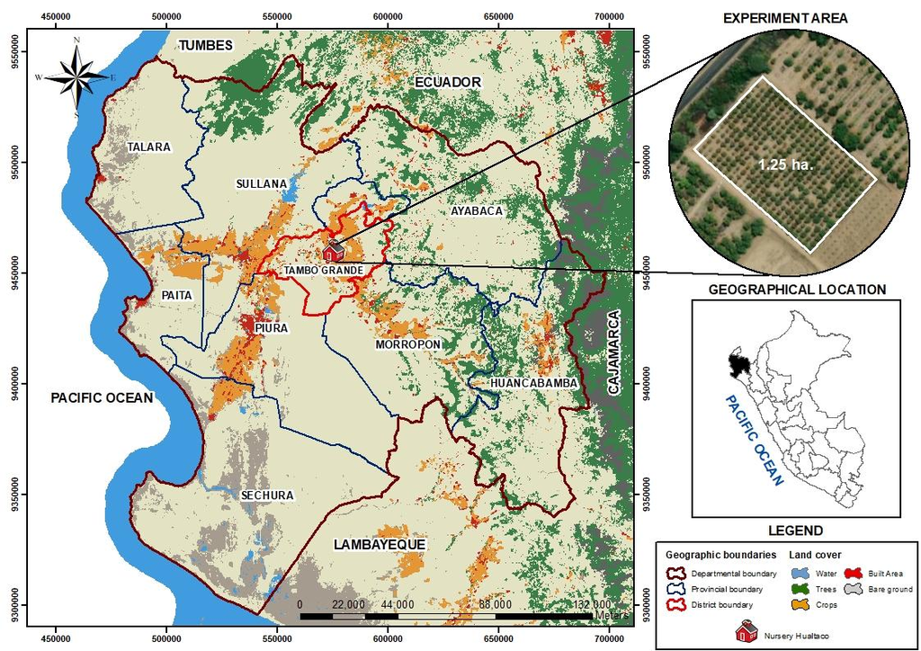

Figure 1: Map of the location of the experimental research area. Hualtaco Nursery, Tambogrande District, Piura Department, Peru.

## 3.2 Plant Material

The rootstocks were obtained from seeds of ‘Chulucanas’ (Chulucanas) and ‘Chato’ (Chato) mangoes propagated in seedbeds with agricultural soil. Afterward, the plants were transplanted into polyethylene bags (16” × 8”) filled with forest agricultural soil substrate. For the interstocks, vegetative buds from the Chulucanas, Chato, ‘Irwin’ (Irwin), and ‘Julie’ (Julie) varieties were used, whereas vegetative buds from the ‘Kent’ (Kent) variety were used for top grafting. The seeds and vegetative buds were acquired from the germplasm bank located at the Hualtaco nursery of EEA-El Chira. The main characteristics of the plant material used are described below:

**Chulucanas:** This variety is known as a criollo variety from Chulucanas in the Piura region, Peru, where the climatic conditions are suitable for its development. This variety is widespread in the northern region of the country and is used as rootstock. It produces yellow and uniform fruit, with a uniquely intense flavor, a high amount of fiber around the seed, and a smaller size than the export mango fruit of CV. Kent [(Hernandez et al., 2021)](https://www.zotero.org/google-docs/?7GSxlc).

**Irwin:** Irwin is one of the most commercially produced and consumed varieties in Japan, Taiwan, South Korea, and Australia and is known as the “apple mango.” Irwin plants are small to medium in height, with oval-shaped fruits that have red skin coloration, measuring approximately 11.5 cm to 13 cm in length and 8 cm to 9 cm in diameter [(Wijethunga et al., 2023)](https://www.zotero.org/google-docs/?qBA17l).

**Julie**: This variety is widespread in Nigeria. The plants exhibit an extended growth habit, with medium foliage density and lanceolate-shaped leaves; the fruit is ovoid with yellow skin coloration, measuring approximately 99.5 mm in length, 70 mm in width, and weighing 219 g [(Esan et al., 2024)](https://www.zotero.org/google-docs/?DR8sW5).

**Chato:** Known as the Chato variety from Ica, it is one of the most widely exploited cultivars in the valley of the Ica region in southern Peru. It is characterized by fruit measuring approximately 151 mm in length and 82 mm in width and weighing 291 g [(Coral & Escobar-Garcia, 2021)](https://www.zotero.org/google-docs/?NcHirf).

Table 1: Treatment Coding of the Study: Impact of Interstock and Rootstock on the Vigor and Productive Development of Mango (*Mangifera indica* L.) in the San Lorenzo Valley, Piura, Peru.

| **Treatment** | **Rootstock** | **Interstock** | **Scion** |
| --- | --- | --- | --- |
| T1 | Chulucanas | Chulucanas | Kent |
| T2 | Chulucanas | Chato | Kent |
| T3 | Chulucanas | Julie | Kent |
| T4 | Chulucanas | Irwin | Kent |
| T5 | Chato | Chulucanas | Kent |
| T6 | Chato | Chato | Kent |
| T7 | Chato | Julie | Kent |
| T8 | Chato | Irwin | Kent |

## 3.3 Agronomic Management

Soil preparation was carried out via a tractor and a harrow, in accordance with the layout of the crop rows, hole digging, and transplanting of seedlings, following a grid planting design of 6 × 6 meters. Seed selection was performed from the mango germplasm bank, which comes from elite plants at the Hualtaco Annex of the El Chira Agricultural Experimental Station (EEA). The process of removing the pericarp, mesocarp, and endocarp facilitated better development of the embryo in the seedlings, which were obtained from polyembryonic seeds in seedbeds. The grafting of the seedlings was performed via the double tongue technique three months after their transplantation into nursery bags. Interstocks and top grafts were subsequently implemented via the same English grafting technique, or double tongue, with an interval of eight months between the two procedures. The bridge rootstock graft was performed in 2008, whereas the bud bridge graft was carried out in 2009.

The irrigation system was established via a technique, starting with one irrigation tape and two microtubes per plant in the first year. A second irrigation tape with two additional microtubes was then added to improve water efficiency. The irrigation schedule was programmed with a frequency of 15-20 days and adjusted according to the crop’s needs. Fertilization was carried out through the combined application of organic fertilizers and synthetic fertilizers, in accordance with the nutritional requirements of the mango at each stage of its development. Weeding was performed periodically via brush cutters, depending on the emergence of weeds in the field. Phytosanitary control was managed under a constant monitoring scheme and integrated pest management. Finally, activities related to flowering, fruiting, and harvesting followed the traditional agronomic practices of local producers in the San Lorenzo Valley.

## 3.4 Agronomic and Biometric Characterization of the Fruit

The agronomic characterization included measuring the plant height, number of fruits, and percentage of budding and flowering. The plant height (m) was determined at the end of the agricultural season. It was measured from the base of the soil to the apex of the plant via a graduated wooden ruler. The number of fruits was determined visually by directly counting the number of fruits produced by each individual before the first harvest. The percentage of budding (%) was determined through direct observation; six branches from the middle third of the canopy on the east side and six branches from the west side were identified and monitored. The number of shoots produced by each branch and the number of buds until desiccation were evaluated [(Lopes et al., 2021)](https://www.zotero.org/google-docs/?HLTDw4). The percentage of flowering (%) was visually assessed by observing the intensity of flowering in the tree canopy at the time of anthesis. The canopy was divided into two opposing sections, and the percentage of flowering was recorded on a scale of 0-100 according to the coverage of the inflorescences in each section. To calculate the overall flowering percentage of the tree, an average of both evaluated sections was taken [(Osuna-Enciso et al., 2023)](https://www.zotero.org/google-docs/?yF4xDY).

To determine the fruit biometrics, five fruits were randomly selected per individual at the time of harvest, and the parameters of fruit weight (g), fruit length (mm), and fruit diameter (mm) were measured. Fruits that reached physiological maturity were chosen for measurements via a Vernier caliper and balance [(Alshallash et al., 2022)](https://www.zotero.org/google-docs/?4pmO10).

## 3.5 Experimental Design

The experiment was conducted via a randomized complete block design (RCBD) with a 2 × 4 factorial arrangement consisting of three blocks. The first factor was the mango rootstock at two levels, the Chulucanas and Chato varieties, and the second factor consisted of the interstock at four levels, the mango varieties Chulucanas, Chato, Irwin, and Julie. The experimental unit was composed of nine mango plants. The treatments consisted of the interaction between the levels of rootstock, interstock, and top grafting of the Kent variety. To determine the agronomic characteristics, all the plants were selected, and the variables measured included plant height, percentage of budding, number of fruits, and percentage of flowering. For the determination of fruit biometrics, five plants were randomly selected, and the variables measured included the weight, length, and diameter of the fruits.

## 3.6 Statistical Analysis

An analysis of variance (ANOVA) was performed to determine if there were differences between the treatments. The comparison of means was carried out via Tukey’s test (α = 0.05) via the R package emmeans [(Lenth et al., 2024)](https://www.zotero.org/google-docs/?2Y17VU). The variables under study were subjected to multivariate analysis via principal component analysis (PCA) via the FactoMineR package [(Husson et al., 2024)](https://www.zotero.org/google-docs/?yGRwzs). The correlation analysis of variables via PCA was conducted via the corrplot package [(Wei et al., 2024)](https://www.zotero.org/google-docs/?ULD9CT). Data analysis was performed via the statistical software R version 4.4.1 [(R Core Team, 2024)](https://www.zotero.org/google-docs/?xZRiwp) **.**

# 4 **RESULTS**

## 4.1 Weather **conditions**

To determine the weather conditions that influenced the management of mango cultivation during the agricultural seasons of 2017–2019, a graph was created with data on maximum temperature, minimum temperature, precipitation, and relative humidity obtained from the “El Partidor” weather station of SENAMHI.

The highest temperature values were recorded in 2018 from January to March, reaching a peak of 35.20 °C in March. On the other hand, the lowest temperature values were observed in 2019 from July to November, reaching 15.72 °C in August. In terms of precipitation, the highest values occurred in 2017 during February and March, peaking at 39.41 mm in March. This was an atypical event caused by the El Niño‒Southern Oscillation (ENSO) climate phenomenon. The relative humidity was also influenced by this event, with a maximum value of 89.48% occurring in March 2017. These parameters are important because they are critical factors that directly influence the growth, flowering, fruiting, and quality of mango fruit.

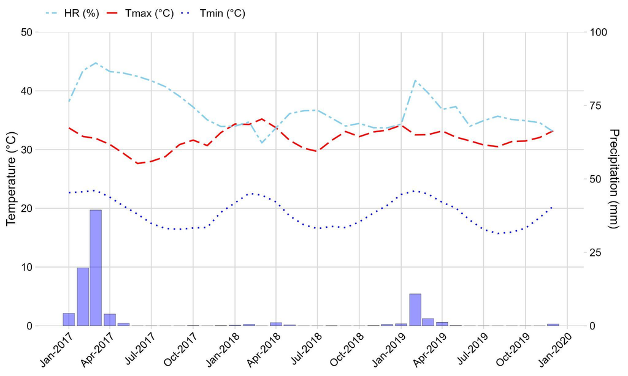

Figure 2: Climatic Conditions During the Agricultural Seasons of 2017-2019, Experiment Located in the District of Tambogrande, Piura Department, Peru. Source: SENAMHI.

## 4.2 Agronomic Characterization

To determine the agronomic characteristics of the rootstock-interstock interaction in the mango, the variables measured included plant height, number of fruits, and percentages of budding and flowering. A univariate analysis was performed via Tukey’s mean comparison test (p < 0.05) to assess whether there were significant differences between the rootstock and the interstock used (Figure 3). This study aimed to identify the rootstock-interstock relationship that exhibits the most favorable agronomic characteristics for enhancing the production and agronomic management of mango (*Mangifera indica* L.) in San Lorenzo Valley.

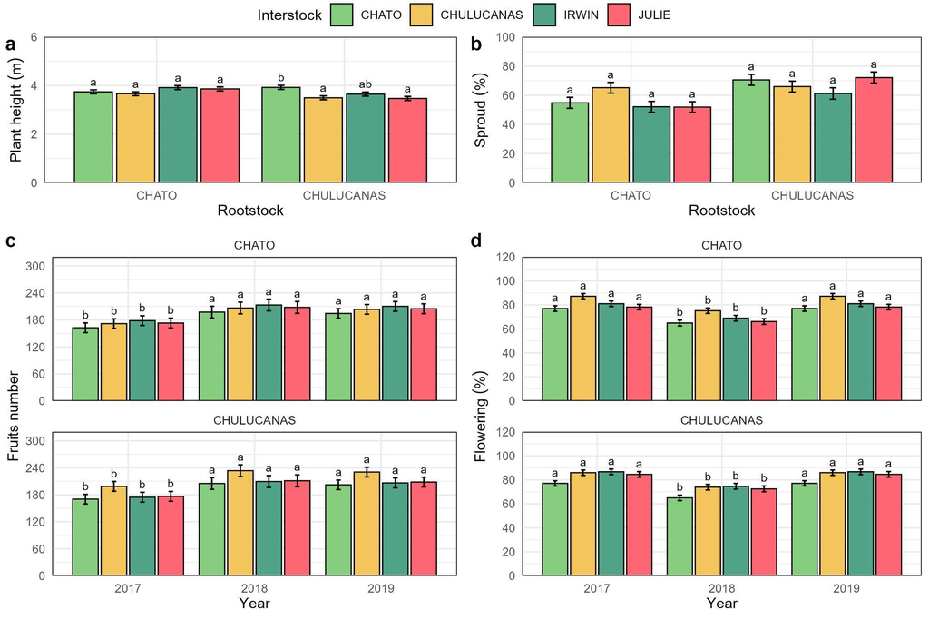

Figure 3: Agronomic Characteristics of the Rootstock and Interstock Relationship for the Mango in the Piura Region, Calculated Based on Nine Plants per Treatment. (a) Plant height at harvest. (b) Percentage of sproud. (c) Number of fruits produced during the agricultural seasons from 2017 to 2019. (d) Percentage of flowering recorded during the agricultural seasons of 2017-2019. Different letters indicate significant differences in Tukey’s mean comparison test (p-value < 0.05, n = 648). Comparison conducted among the interstock varieties within each rootstock.

For the variable plant height, significant differences were observed between the interactions of rootstock and interstock (p-value < 0.01). The results showed that the Chuluca rootstock with the Chulucanas and Julie interstocks had lower means for the plant height variable, measuring 3.49 m and 3.46 m, respectively (Figure 3a). The Chato rootstock, on the other hand, did not significantly differ among the various interstocks used. However, the Chato rootstock, on average, achieved greater heights of 3.80 m than did the Chulucanas rootstock at 3.63 m, suggesting that the use of the latter yields better results for this variable, particularly highlighting the Chulucans-Chulucans and Chulucans-Julie relationships.

There were no significant differences in the percentage of buds among the interstocks used for each rootstock (p value > 0.05). However, for Chulucanas, higher average values were recorded for this variable, with a value of 67.47% compared with 55.99% for the Chato rootstock. The interaction of the Chulucanas-Julie rootstock-interstock combination had the highest percentage of buds, at 72.16% (Figure 3b).

For the variable number of fruits, no significant differences were observed for each rootstock or the different interstocks used (p-value = 0.46). In contrast, significant differences were observed between the agricultural seasons of 2017 and 2019 for both rootstocks (p-value < 0.001). In the case of the Chato rootstock, the number of fruits produced was lower on average in 2017, at 171.40, than in 2018 and 2019, with averages of 206.15 and 203.18, respectively. Similarly, for the Chulucanas rootstock, in 2017, an average lower number of fruits were produced 180.16, than in 2018 and 2019, with averages of 214.90 and 211.94, respectively. Furthermore, the results indicated that the Chulucanas rootstock produced higher values for this variable, with an average of 202.33 fruits, compared with 193.57 for the Chato rootstock. (Figure 3c).

To analyze the overall interaction of the variables and the use of rootstocks, a multivariate analysis of principal components (PCA) and a Pearson correlation analysis were conducted (Figure 4, Supplementary Figure 1).

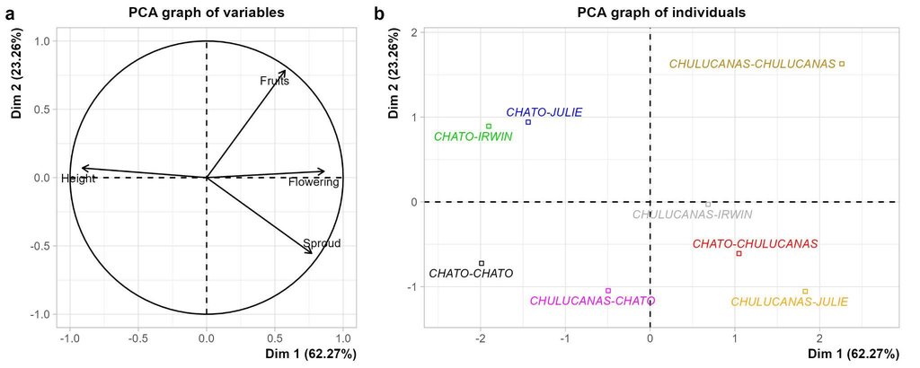

Figure 4: Principal Component Analysis (PCA) of the agronomic characteristics in mango cultivation based on the use of rootstock-interstock combinations. (a) Variables were evaluated to determine the agronomic characteristics of the rootstock-interstock combination in mango. (b) Treatments were used based on the rootstock-interstock combination for evaluating the agronomic characteristics of mango plants. The analysis was based on 648 observations (n = 648).

To evaluate the interaction of the variables, a multivariate principal component analysis (PCA) method was used (Figure 4). The first two components represent 85.52% of the cumulative variance, accounting for 62.27% of the variance in dimension 1 and 23.26% in dimension 2 (Figure 4a, Supplementary Figure 1a). For dimension 1, the variables plant height and percentage of flowering contributed 33.26% and 29.71%, respectively, whereas the percentage of budding contributed 23.77% and the number of fruits contributed 13.26% (Figure 4a, Supplementary Figure 1b). In dimension 2, the variable number of fruits and percentage of buds had the greatest contributions, at 66.19% and 33.05%, respectively, whereas the percentage of flowers was 0.23% and plant height was 0.53%. (Figure 4a, Supplementary Figure 1c).

The vectors indicate the direction of the relationship between the variables, showing a positive relationship among the variables of budding, flowering, and number of fruits produced, in contrast to plant height, where a negative relationship is observed. Notably, there was a strong positive correlation (0.86) between the percentage of flowering and a strong negative correlation (-0.91) between the plant height variable and dimension 1. Furthermore, in dimension 2, the variable number of fruits had a strong positive correlation of 0.78 (Figure 4a, Supplementary Figure 1d).

## 4.3 Biometric characterization of the fruit

| **Variable** | **Rootstock** | **Interstock** | **mean** | **sd** | **min** | **max** | **Sig** |
| --- | --- | --- | --- | --- | --- | --- | --- |
| Fruit Weight (g) | Chato | Chato | 452.53 | 79.92 | 305 | 639 | a |
|  | Chato | Chulucanas | 462.34 | 69.82 | 340 | 620 | a |
|  | Chato | Irwin | 482.03 | 87.3 | 350 | 700 | a |
|  | Chato | Julie | 465.97 | 92.07 | 300 | 645 | a |
|  | Chulucanas | Chato | 484.97 | 101.98 | 316 | 765 | a |
|  | Chulucanas | Chulucanas | 468.17 | 118.73 | 230 | 665 | a |
|  | Chulucanas | Irwin | 447.23 | 70.09 | 310 | 605 | a |
|  | Chulucanas | Julie | 484.7 | 93.46 | 367 | 717 | a |
| Fruit length (mm) | Chato | Chato | 105.97 | 6.78 | 93 | 120 | a |
|  | Chato | Chulucanas | 106.28 | 6.8 | 94 | 119 | a |
|  | Chato | Irwin | 106.07 | 6.47 | 95 | 124 | a |
|  | Chato | Julie | 107.67 | 7.54 | 91 | 120 | a |
|  | Chulucanas | Chato | 106.53 | 7.21 | 95 | 123 | a |
|  | Chulucanas | Chulucanas | 106.2 | 10.87 | 86 | 126 | a |
|  | Chulucanas | Irwin | 106.43 | 7.28 | 92 | 122 | a |
|  | Chulucanas | Julie | 109.73 | 8.03 | 98 | 129 | a |
| Fruit diameter (mm) | Chato | Chato | 85.23 | 4.72 | 76 | 97.5 | a |
|  | Chato | Chulucanas | 86.09 | 3.61 | 78.5 | 93.5 | a |
|  | Chato | Irwin | 87.63 | 5.07 | 79.5 | 100 | a |
|  | Chato | Julie | 86.23 | 5.56 | 75.5 | 97.5 | a |
|  | Chulucanas | Chato | 87.7 | 5.4 | 78 | 100.5 | a |
|  | Chulucanas | Chulucanas | 86.08 | 6.61 | 69.5 | 99 | a |
|  | Chulucanas | Irwin | 84.53 | 4.03 | 77.5 | 92.5 | a |
|  | Chulucanas | Julie | 86.3 | 4.68 | 79.5 | 97 | a |

To analyze the overall interaction of the variables and the use of rootstocks, a multivariate analysis of principal components (PCA) and a Pearson correlation analysis were conducted (Figure 5, Supplementary Figure 2).

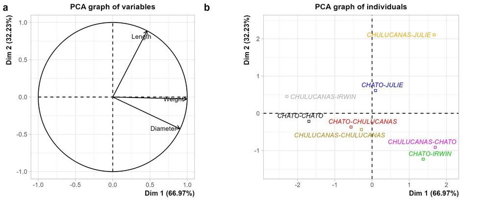

Figure 5: Principal Component Analysis (PCA) of fruit biometrics in mango cultivation based on the use of rootstock-interstock combinations. (a) Variables were evaluated to determine the fruit quality of the rootstock-interstock combination in mango. (b) Treatments were used based on the rootstock-interstock combination for evaluating fruit quality in mango plants. The analysis was based on 240 observations (n = 240).

To evaluate the interaction of the variables, a multivariate principal component analysis (PCA) method was used (Figure 5). The first two components represent 99.21% of the cumulative variance, with 66.97% of the variance in dimension 1 and 32.23% in dimension 2 (Figure 5a, Supplementary Figure 2a). For dimension 1, the variables weight and diameter of the fruit contributed the most to this dimension, with 49.14% and 40.32%, respectively, whereas the contribution of fruit length was 10.55%. (Figure 5a, Supplementary Figure 2b). In dimension 2, the variable fruit length had the greatest contribution, at 81.29%, compared with the contributions of weight and fruit diameter, which were 0.07% and 18.64%, respectively (Figure 5a, Supplementary Figure 2c).

The vectors indicate the direction of the relationship between the variables, highlighting a notable degree of positive correlation among the weight, length, and diameter of the fruits. Notably, there was a strong positive correlation for fruit weight (0.99) and fruit diameter (0.90) with respect to dimension 1. Additionally, in dimension 2, the variable fruit length has a strong positive correlation of 0.89 (Figure 5a, Figura Suplementaria 2d).

On the other hand, it is observed that the Chulucanas-Julie rootstock-interstock relationship is aligned with the vector for fruit length, indicating that individuals with this graft exhibit better characteristics for this variable. In terms of fruit weight, individuals with the Chulucanas-Chato and Chato-Irwin relationships presented the highest values. In terms of fruit diameter, the Chulucanas-Chato and Chato-Irwin rootstock-interstock relationships also presented the highest means.

# 5 **DISCUSSIONS**

The mango is considered one of the most important export fruits in Peru. Sixty-six point seven percent (66.7%) of the mango harvest is produced in the Piura department, making it the country’s leading producer [(Coral & Escobar-Garcia, 2021)](https://www.zotero.org/google-docs/?qUQP2i). Despite the large quantity of mango produced, there is still low productivity per unit area, which significantly impacts exports. The use of rootstocks influences the growth of mango plants in terms of height, diameter, and canopy volume, potentially inducing dwarfism in individuals and thereby increasing the planting density per hectare [(Dubey et al., 2021)](https://www.zotero.org/google-docs/?th5Vgb). This research evaluated the effects of rootstock and interstock on the agronomic characteristics and fruit quality of mango. The growth and productivity parameters that determine the production of mango in the San Lorenzo Valley, Piura, were assessed.

On the other hand, in our study, fruit budding was not influenced by the graft used. These results differ from those presented by [(Hamza et al., 2023)](https://www.zotero.org/google-docs/?pNcBc8), who evaluated three graft varieties (Sinddhri, Sufaid Chaunsa, Chenab Gold) at three different heights; their results revealed that the variety of the graft significantly increased the number of shoots produced. This difference may also be attributed to the variety of grafts used, as the production of shoots in different mango varieties can vary significantly due to genetic factors, resulting in differences in budding intensity [(Emire et al., 2022)](https://www.zotero.org/google-docs/?MuotqP). Therefore, it is presumed that the graft varieties used by the authors have greater genetic differences than the varieties employed in the present study. For flowering and the number of fruits, our results were also not influenced by the graft used. However, differences were observed between the years of evaluation. These differences may be due to changes in climate caused by the El Niño‒Southern Oscillation (ENSO) phenomenon. As noted by [(Scuderi et al., 2023)](https://www.zotero.org/google-docs/?Bgc3LW), environmental factors can influence the development of flowering and, consequently, the number of fruits produced during mango cultivation.

[(Rebolledo-Martínez et al., 2019)](https://www.zotero.org/google-docs/?3Zp97f) evaluated the grafting of the “Manila” mango on short (Thomas and Julie), medium (Esmeralda, Irwin Morado, Gomera 1, and Chauza), and tall (Creole) rootstocks. Their results revealed that the Julie rootstock had a positive effect on height, stem diameter, and fruit production. In our study, the interaction of rootstocks and interstocks influenced the evaluated variables, playing an important role in achieving favorable agronomic characteristics (Figure 3, Figure 4, Table 1).

In the evaluation of mango fruit biometrics, the interaction between the rootstock and the graft did not have a significant effect on the expression of characteristics of the variables of weight, length, and diameter during the agricultural seasons from 2017-2019 (Table 2, Figure 5). The highest weight values were recorded with the Chulucanas-Chato and Chulucanas-Julie combinations (Table 2); therefore, it can be assumed that the Chulucanas variety used as rootstock has a direct relationship with fruit weight. However, [(Shivran et al., 2023)](https://www.zotero.org/google-docs/?bozTsv) reported that during the rootstock-cion interaction in mango, the fruit weight variable is determined by the scion.

In our study, during the year 2017, the El Niño Southern Oscillation (ENSO) climate phenomenon occurred, which increased the precipitation and temperature in the San Lorenzo Valley (Figure 2). As a result, the variables of flowering and fruit biometrics may have been affected, as reports from authors indicate that these environmental conditions cause premature fruit drop and decrease tree health, vigor, and compatibility in certain rootstocks and scions [(Dubey et al., 2021)](https://www.zotero.org/google-docs/?PJvUIh); [(Halder et al., 2024)](https://www.zotero.org/google-docs/?pssLgC).

Among the limitations of this study is that the evaluations of all the variables were not conducted in consecutive years, which would have allowed for a more detailed assessment of plant height, budding, and fruit biometrics. This omission was primarily due to financial constraints, which limited the possibility of carrying out continuous data collection. Additionally, cases of regression death were recorded in the plants, resulting in incomplete evaluations of the experimental units within each treatment. Despite the limitations presented, the results of this study contribute to understanding the dynamics of interstocks in improving the agronomic and biometric characteristics of mango fruit, potentially serving as an alternative to enhance the agronomic management of the crop and benefiting producers in San Lorenzo Valley.

To address the future challenges associated with this technique, it is crucial to evaluate the quality of the fruits produced. In this context, research analyzing parameters such as fruit firmness, titratable acidity, soluble solids content, and percentage of dry matter is recommended. These attributes are essential to ensure consumer acceptance and competitiveness in both local and international markets. Investigating these aspects could not only improve mango crop management but also help farmers increase their productivity and ensure that fruit quality meets export standards and the preferences of the end consumer.

# 6 **CONCLUSIONS**

The use of rootstocks in combination with interstocks influences the agronomic characteristics of mango cultivation, although it does not affect the biometrics of mango fruits. This study demonstrated that the variety of cultivars used affects plant growth; however, no significant differences in the biometric characteristics of the fruits were detected. The obtained data confirm that interstocks can induce a dwarfing effect in plants, allowing for increased planting density per hectare. This information regarding plant behavior based on the type of graft used can be valuable for optimizing the agronomic management of mango cultivation in the Piura region of Peru.

# 7 **REFERENCES**

[Alshallash, K. S., Sharaf, M., Hmdy, A. E., Khalifa, S. M., Abdel-Aziz, H. F., Sharaf, A., Ibrahim, M. T. S., Alharbi, K., & Elkelish, A. (2022). Hydrogel Improved Growth and Productive Performance of Mango Trees under Semi-Arid Condition. *Gels*, *8*(10), Article 10. https://doi.org/10.3390/gels8100602](https://www.zotero.org/google-docs/?vf6UzE)

[Bally, I. S. E., Johnson, P. R., & Kulkarni, V. J. (2000). Mango production in Australia. *Acta Horticulturae*, *509*, 59-68. https://doi.org/10.17660/ActaHortic.2000.509.3](https://www.zotero.org/google-docs/?vf6UzE)

[Baron, D., Esteves Amaro, A. C., Pina, A., & Ferreira, G. (2019). An overview of grafting re-establishment in woody fruit species. *Scientia Horticulturae*, *243*, 84-91. https://doi.org/10.1016/j.scienta.2018.08.012](https://www.zotero.org/google-docs/?vf6UzE)

[Beshir, W., Alemayehu, M., & Dessalegn, Y. (2019). Effect of grafting time and technique on the success rate of grafted Mango (*Mangifera indica* L.) in Kalu District of Amhara Region, North Eastern Ethiopia. *Cogent Food & Agriculture*, *5*(1), 1577023. https://doi.org/10.1080/23311932.2019.1577023](https://www.zotero.org/google-docs/?vf6UzE)

[Castle, W. S., Bowman, K. D., Baldwin, J. C., Grosser, J. W., & Gmitter, F. G. (2011). Rootstocks Affect Tree Growth, Yield, and Juice Quality of ‘Marsh’ Grapefruit. *HortScience*, *46*, 841-848. https://doi.org/10.21273/HORTSCI.46.6.841](https://www.zotero.org/google-docs/?vf6UzE)

[Coral, L. L. T., & Escobar-Garcia, H. A. (2021). Characterization of fruits of varieties of mango (*Mangifera indica*) conserved in Peru. *Revista Brasileira de Fruticultura*, *43*, 8. https://doi.org/10.1590/0100-29452021710](https://www.zotero.org/google-docs/?vf6UzE)

[Dayal, V., Dubey, A. K., Singh, S. K., Sharma, R. M., Dahuja, A., & Kaur, C. (2016). Growth, yield and physiology of mango (*Mangifera indica* L.) cultivars as affected by polyembryonic rootstocks. *Scientia Horticulturae*, *199*, 186-197. https://doi.org/10.1016/j.scienta.2015.12.042](https://www.zotero.org/google-docs/?vf6UzE)

[Dubey, A. K., Sharma, R. M., Deepak, & Kumar, A. (2021). Long term performance of mango varieties on five polyembryonic rootstocks under subtropical conditions: Effect on vigour, yield, fruit quality and nutrient acquisition. *Scientia Horticulturae*, *280*, 109944. https://doi.org/10.1016/j.scienta.2021.109944](https://www.zotero.org/google-docs/?vf6UzE)

[El Shahawy, S. A., Nomier, S. A. A., Mohsen, F. M. S., & Gad, M. M. (2023). Identification of the Promising Mango Rootstocks and their Response to Grafting of some Foreign Mango Cultivarsin the nursery. *Zagazig Journal of Agricultural Research*, *50*(1), 43-53. https://doi.org/10.21608/zjar.2023.290092](https://www.zotero.org/google-docs/?vf6UzE)

[Emire, A., Demise, S., Giri, T., & Tadele, W. (2022). Growth and Yield Performance Evaluation of Mango (*Mangifera indica* L *.*) Varieties in Adola Rede District, Guji Zone, Southern Ethiopia. *American Journal of Plant Biology*, *7*(3), Article 3. https://doi.org/10.11648/j.ajpb.20220703.14](https://www.zotero.org/google-docs/?vf6UzE)

[Esan, V. I., Ogunbode, T. O., Ogunlaran, O. M., Ayegboyin, M. H., Omilani, O. O., Sangoyomi, T. E., & Akande, J. A. (2024). Genetic Variability and Morpho-Agronomic Characterization of Some Mango (*Mangifera indica* L.) Cultivars and Varieties in Nigeria. *International Journal of Fruit Science*, *24*(1), 256-272. https://doi.org/10.1080/15538362.2024.2389102](https://www.zotero.org/google-docs/?vf6UzE)

[Feng, M., Augstein, F., Kareem, A., & Melnyk, C. W. (2024). Plant grafting: Molecular mechanisms and applications. *Molecular Plant*, *17*(1), 75-91. https://doi.org/10.1016/j.molp.2023.12.006](https://www.zotero.org/google-docs/?vf6UzE)

[Halder, R., Varma, S., Singh, M., & Dahiya, A. (2024). From orchard to table: Understanding climate change impacts on mango production in India: A review. *International Journal of Advanced Biochemistry Research*, *8*(4), 472-478. https://doi.org/10.33545/26174693.2024.v8.i4f.1015](https://www.zotero.org/google-docs/?vf6UzE)

[Hamza, A., Razzaq, K., Umair, M., Hussain, A., Zafar, M. S., & Rehman, A. U. (2023). Standardization of Grafting Height for Growth and Development of Mango (*Mangifera indica* L.) Nursery Plants. *Data Plus*, *1*(2), Article 2. https://doi.org/10.62887/dataplus.001.01.0012](https://www.zotero.org/google-docs/?vf6UzE)

[Hernandez, E., Sôcola, Z., Choque, T., & Hernandez, M. (2021). Evaluation of the Color of Mango Puree (*Mangifera Indica*) Creole Variety of Chulucanas Influenced by the Size of the Refined Pulp and Interaction Time to Environmental Air. *Journal of Physics: Conference Series*, *1828*(1), 1-6. https://doi.org/10.1088/1742-6596/1828/1/012128](https://www.zotero.org/google-docs/?vf6UzE)

[Honja, T. (2014). Review of Mango Value Chain in Ethiopia. *Journal of Biology, Agriculture and Healthcare*, *4*(25), 230-239.](https://www.zotero.org/google-docs/?vf6UzE)

[Husson, F., Josse, J., Le, S., & Mazet, J. (2024). *FactoMineR: Multivariate Exploratory Data Analysis and Data Mining*. https://doi.org/10.32614/CRAN.package.FactoMineR](https://www.zotero.org/google-docs/?vf6UzE)

[Ibell, P. T., Normand, F., Wright, C. L., Mahmud, K., & Bally, I. S. E. (2024). The Effects of Planting Density, Training System and Cultivar on Vegetative Growth and Fruit Production in Young Mango (*Mangifera indica* L.) Trees. *Horticulturae*, *10*(9), Article 9. https://doi.org/10.3390/horticulturae10090937](https://www.zotero.org/google-docs/?vf6UzE)

[Johnson, P. R., & Robinson, D. M. (2000). The Tatura trellis system for high density mangoes. *Acta Horticulturae*, *509*, 359-364. https://doi.org/10.17660/ActaHortic.2000.509.41](https://www.zotero.org/google-docs/?vf6UzE)

[Jukić Špika, M., Dumičić, G., Brkić Bubola, K., Soldo, B., Goreta Ban, S., Vuletin Selak, G., Ljubenkov, I., Mandušić, M., & Žanić, K. (2021). Modification of the Sensory Profile and Volatile Aroma Compounds of Tomato Fruits by the Scion × Rootstock Interactive Effect. *Frontiers in Plant Science*, *11*. https://doi.org/10.3389/fpls.2020.616431](https://www.zotero.org/google-docs/?vf6UzE)

[Khurshid, T., Creek, A., Sanderson, G., & Zhao, X. (2024). Tree Performance, Yield, and Fruit Quality of ‘Valencia’ Sweet Orange (*Citrus sinensis* L. Osbeck) Selections on New Poncirus trifoliata Rootstocks. *Horticulturae*, *10*(4), Article 4. https://doi.org/10.3390/horticulturae10040393](https://www.zotero.org/google-docs/?vf6UzE)

[Lazare, S., Haberman, A., Yermiyahu, U., Erel, R., Simenski, E., & Dag, A. (2019). Avocado rootstock influences scion leaf mineral content. *Archives of Agronomy and Soil Science*, *66*(10), 1399-1409. https://doi.org/10.1080/03650340.2019.1672163](https://www.zotero.org/google-docs/?vf6UzE)

[Lenth, R. V., Bolker, B., Buerkner, P., Giné-Vázquez, I., Herve, M., Jung, M., Love, J., Miguez, F., Piaskowski, J., Riebl, H., & Singmann, H. (2024). *emmeans: Estimated Marginal Means, aka Least-Squares Means* (Versión 1.10.4) [Software]. https://cran.r-project.org/web/packages/emmeans/index.html](https://www.zotero.org/google-docs/?vf6UzE)

[Lopes, R. de C., Pereira, R. N., Silva, L. dos S., Lobo, J. T., Araújo e Amariz, R., & Cavalcante, Í. H. L. (2021). Impact of First Mechanical Fructification Pruning on Mango Orchards. *International Journal of Fruit Science*, *21*(1), 1059-1072. https://doi.org/10.1080/15538362.2021.1989358](https://www.zotero.org/google-docs/?vf6UzE)

[Lu, P., Chacko, E. K., Bithell, S. L., Schaper, H., Wiebel, J., Cole, S., & Müller, W. J. (2013). Productivity is negatively related to shoot growth across five mango cultivars in the seasonally wet-dry tropics of northern Australia. *Fruits*, *68*(4), 279-289. https://doi.org/10.1051/fruits/2013074](https://www.zotero.org/google-docs/?vf6UzE)

[Martínez-Ballesta, M. C., Alcaraz-López, C., Muries, B., Mota-Cadenas, C., & Carvajal, M. (2010). Physiological aspects of rootstock–scion interactions. *Scientia Horticulturae*, *127*(2), 112-118. https://doi.org/10.1016/j.scienta.2010.08.002](https://www.zotero.org/google-docs/?vf6UzE)

[Menzel, C. M., & Le Lagadec, M. D. (2017). Can the Productivity of Mango Orchards be Increased by Using High-Density Plantings? *Scientia Horticulturae*, *219*, 222-263. https://doi.org/10.1016/j.scienta.2016.11.041](https://www.zotero.org/google-docs/?vf6UzE)

[Minja, R. R., Kimaro, A. A., Mpanda, M., Moshy, S., Mwaijande, V., Ngereza, A., Ambrose, J., Ndee, A., Kihula, B., & Nyalusi, G. (2017). Effects of Rootstock Type and Scion Cultivar on Grafting Success and Growth of Mango (*Mangifera indica* L.) Seedlings. *Journal of Experimental Agriculture International*, 1-9. https://doi.org/10.9734/JEAI/2017/32129](https://www.zotero.org/google-docs/?vf6UzE)

[Moniruzzaman, M., Uddin, M. S., Akhter, M. A. E., Tripathi, A., & Rahaman, K. R. (2022). Application of Geospatial Techniques in Evaluating Spatial Variability of Commercially Harvested Mangoes in Bangladesh. *Sustainability*, *14*(20), Article 20. https://doi.org/10.3390/su142013495](https://www.zotero.org/google-docs/?vf6UzE)

[Osuna-Enciso, T., Pérez-Barraza, M. H., Martínez-Alvarado, C. O., Hernández-Verdugo, S., Osuna-Rodríguez, J. M., & Martín-Matheis, H. S. (2023). Retraso de Floración y Calidad del Fruto de Mango Kent en el Sur de Sinaloa, México. *Revista Fitotecnia Mexicana*, *46*(4), 389-389. https://doi.org/10.35196/rfm.2023.4.389](https://www.zotero.org/google-docs/?vf6UzE)

[R Core Team. (2024). *R: A Language and Environment for Statistical Computing* (Versión 4.4.1) [Software]. R Foundation for Statistical Computing. https://www.R-project.org/](https://www.zotero.org/google-docs/?vf6UzE)

[Rebolledo-Martínez, A., Peralta-Antonio, N., Rebolledo-Martínez, L., Becerril-Román, E. A., & Rebolledo-García, R. L. (2019). Effect of Rootstock in Tree Growth, Dry Matter, Flowering, Yield and Quality of ‘Manila’ Mango. *Scientia Horticulturae*, *251*, 155-161. https://doi.org/10.1016/j.scienta.2019.03.012](https://www.zotero.org/google-docs/?vf6UzE)

[Reddy, Y. T. N., Kurian, R. M., Ramachander, P. R., Singh, G., & Kohli, R. R. (2003). Long-term effects of rootstocks on growth and fruit yielding patterns of ‘Alphonso’ mango (*Mangifera indica* L.). *Scientia Horticulturae*, *97*(2), 95-108. https://doi.org/10.1016/S0304-4238(02)00025-0](https://www.zotero.org/google-docs/?vf6UzE)

[Scuderi, D., Gianguzzi, G., Tinebra, I., Gugliuzza, G., & Farina, V. (2023). Phenology and Fruit Growth Dynamics of Mango (*Mangifera indica* L.) in Greenhouse and Open Air in Mediterranean Climate. *Proceedings of the National Academy of Sciences, India Section B: Biological Sciences*, *93*(3), 731-741. https://doi.org/10.1007/s40011-023-01475-2](https://www.zotero.org/google-docs/?vf6UzE)

[Shivran, M., Sharma, N., Dubey, A. K., Singh, S. K., Sharma, N., Muthusamy, V., Jain, M., Singh, B. P., Singh, N., Kumar, N., Singh, N., Sethi, S., & Sharma, R. M. (2023). Scion/Rootstock Interaction Studies for Quality Traits in Mango (*Mangifera indica* L.) Varieties. *Agronomy*, *13*(1), Article 1. https://doi.org/10.3390/agronomy13010204](https://www.zotero.org/google-docs/?vf6UzE)

[Silva, A. C. da, Souza, A. P. de, Leonel, S., Souza, M. E. de, Ramos, D. P., & Tanaka, A. A. (2014). Growth and Flowering of Five Mango Cultivar under Subtropics Conditions of Brazil. *American Journal of Plant Sciences*, *5*(3), Article 3. https://doi.org/10.4236/ajps.2014.53052](https://www.zotero.org/google-docs/?vf6UzE)

[Smith, M. W., Bright, J. D., Hoult, M. D., Renfree, R. A., Maddern, T., & Coombes, N. (2008). Field Evaluation of 64 Rootstocks for Growth and Yield of ‘Kensington Pride’ Mango. *HortScience*, *43*(6), 1720-1725. https://doi.org/10.21273/HORTSCI.43.6.1720](https://www.zotero.org/google-docs/?vf6UzE)

[Souza, M. P., Queiroz, M. A., Possídio, E. L., Pereira, F. A., & Nunes, R. F. M. (2004). Study of Flowering and Alternate Bearing of Mango Varieties in the São Francisco Valley. *Acta Horticulturae*, *645*, 353-358. https://doi.org/10.17660/ActaHortic.2004.645.43](https://www.zotero.org/google-docs/?vf6UzE)

[Tietel, Z., Srivastava, S., Fait, A., Tel-Zur, N., Carmi, N., & Raveh, E. (2020). Impact of scion/rootstock reciprocal effects on metabolomics of fruit juice and phloem sap in grafted *Citrus reticulata*. *PLOS ONE*, *15*(1), e0227192. https://doi.org/10.1371/journal.pone.0227192](https://www.zotero.org/google-docs/?vf6UzE)

[Wei, T., Simko, V., Levy, M., Xie, Y., Jin, Y., Zemla, J., Freidank, M., Cai, J., & Protivinsky, T. (2024). *corrplot: Visualization of a Correlation Matrix*. https://doi.org/10.32614/CRAN.package.corrplot](https://www.zotero.org/google-docs/?vf6UzE)

[Wijethunga, W. M. U. D., Shin, M. H., Jayasooriya, L. S. H., Kim, G. H., Park, K. M., Cheon, M. G., Choi, S. W., Kim, H. L., & Kim, J. G. (2023). Evaluation of Fruit Quality Characteristics in ‘Irwin’ Mango Grown via Forcing Cultivation in a Plastic Facility. *Horticultural Science and Technology*, *41*(6), 617-633. https://doi.org/10.7235/HORT.20230053](https://www.zotero.org/google-docs/?vf6UzE)